# A socioeconomic study of standardized test scores in New York State schools

Uygar Sozer

9/15/2020

```r
#Load required packages
library(tidyverse)
library(lubridate)
library(data.table)
```

```r
#Reading in the data
acs <- fread("../data/nys_acs.csv")
schools <- fread("../data/nys_schools.csv")
```

## Exploring the data

acs dataset contains no missing variables. schools dataset does contain missing variables, coded in various ways. We will apply cleaning function to both datasets.

```r
#Converts all -99 values to NA, input: vector, output: vector with NA
naconvert <- function(x) {
  x = na_if(x, -99)
  x = na_if(x, "")
}
#Mutate datasets with respect to -99 values
schools <- schools %>% mutate(across(.fns = naconvert))
acs <- acs %>% mutate(across(.fns = naconvert))
```

We will add a categorical variable poverty_level that categorizes counties based on median household income, with cutoffs 0.33 and 0.66 quantiles for low, medium, and high, respectively.

```r
#Define the cutoffs for each category
pov_cutoff = quantile(acs$median_household_income, c(0.33, 0.66))

##acs %>% filter(median_household_income < pov_cutoff[1]) %>% mutate(poverty_level = "high")
##acs %>% filter(median_household_income >= pov_cutoff[1] & median_household_income < pov_cutoff[2] ) %>% mutate(poverty_level = "medium")
##acs %>% filter(median_household_income >= pov_cutoff[2]) %>% mutate(poverty_level = "low")

#Assign each category
acs[median_household_income < pov_cutoff[1], poverty_level := "high"]
acs[median_household_income >= pov_cutoff[1] & median_household_income < pov_cutoff[2], poverty_level :="medium"]
acs[median_household_income >= pov_cutoff[2], poverty_level := "low"]
```

We will introduce scaled/normalized variables for mean reading and math scores per school, based on the population mean and SD each year.

```r
#Normalizes reading and math scores
schools[, z_ela_score := scale(mean_ela_score), by=year]
schools[, z_math_score := scale(mean_math_score), by=year]
```

## Analysis for 2016

For this section, we will be looking the most recent data from 2016.

```r
#Merge data.tables, create a new data.table restricted to 2016
merged_schools <- merge(schools, acs, all.x = TRUE)

#Adjust poverty_level variable to be a factor (instead of character)
merged_schools[,poverty_level := factor(poverty_level, levels = c("low", "medium", "high"))]

#New data.table restricted to 2016
merged_schools06 <- merged_schools[year=="2016"]
```

Data from NYS does not provide the exact number of students receiving lunch subsidy, but we have access to the percentages. Based on this, we can calculate the percentage of students on lunch subsidy in each county, weighted by student population per school.

```r
#Add a new variable denoting appx. number of students that receive free or reduced-price lunch
merged_schools06[, lunch_subsidy := (per_free_lunch + per_reduced_lunch)*total_enroll]

#Return a summary table per county
merged_schools06[,.(total_enrollment = sum(total_enroll, na.rm=T), per_lunch_subsidy = sum(lunch_subsidy, na.rm=T)/sum(total_enroll, na.rm=T), per_poverty = mean(county_per_poverty, na.rm=T)), by = county_name]
```

```
##        county_name total_enrollment per_lunch_subsidy per_poverty
##  1:         ALBANY            25895         0.4072667  0.12260508
##  2:       ALLEGANY             5569         0.5717220  0.15270440
##  3:          BRONX           178274         0.8422199  0.29768894
##  4:         BROOME            18560         0.5377883  0.16528440
##  5:    CATTARAUGUS             9051         0.5444072  0.16896798
##  6:         CAYUGA             5727         0.4890781  0.10781514
##  7:     CHAUTAUQUA            13445         0.5709617  0.18527795
##  8:        CHEMUNG             9054         0.5307809  0.15020173
##  9:       CHENANGO             5576         0.5516589  0.15152376
## 10:        CLINTON             7053         0.5176379  0.14557389
## 11:       COLUMBIA             4409         0.4919143  0.12293889
## 12:       CORTLAND             3561         0.5531733  0.12746084
## 13:       DELAWARE             4578         0.5681018  0.15032272
## 14:       DUTCHESS            24365         0.3294784  0.08638583
```

[output cut: 49 more lines]

When we look at the highest and lowest-earning counties in NYS by percentage of population under poverty line, we observe that most test scores for high-earning counties were above state average in both math and reading; the opposite is true for the low-earning counties.

```r
#Define top 5 and bottom 5 counties ordered by percent poverty
topcounties <- acs[year==2016][order(county_per_poverty)][1:5, county_name]
bottomcounties <- acs[year==2016][order(-county_per_poverty)][1:5, county_name]

#Return two table percent poverty, mean math and reading scores, grouped by county
merged_schools06[county_name %in% topcounties,.(per_poverty = mean(county_per_poverty), per_lunch_subsidy = sum(lunch_subsidy)/sum(total_enroll), mean_ela = mean(z_ela_score, na.rm=T), mean_math = mean(z_math_score, na.rm=T)),by=county_name]
```

```
##    county_name per_poverty per_lunch_subsidy    mean_ela  mean_math
## 1:    DUTCHESS  0.08638583         0.3294784 -0.05198409 -0.1199382
## 2:      NASSAU  0.05917006         0.2885964  0.80850744  0.7843294
## 3:      PUTNAM  0.05091140         0.2077059  0.51349150  0.4480265
## 4:    SARATOGA  0.06309991         0.2404059  0.53061529  0.6942077
## 5:     SUFFOLK  0.07108796         0.3852206  0.17736813  0.1669567
```

```r
merged_schools06[county_name %in% bottomcounties, .(per_poverty = mean(county_per_poverty), per_lunch_subsidy = sum(lunch_subsidy)/sum(total_enroll), mean_ela = mean(z_ela_score, na.rm=T), mean_math = mean(z_math_score, na.rm=T)),by=county_name]
```

```
##    county_name per_poverty per_lunch_subsidy      mean_ela   mean_math
## 1:       BRONX   0.2976889         0.8422199 -0.4830324498 -0.64968435
## 2:  CHAUTAUQUA   0.1852780         0.5709617 -0.3812601463 -0.18609916
## 3:       KINGS   0.2253745         0.7202267  0.0009265214 -0.16985020
## 4:  MONTGOMERY   0.2016228         0.5718805 -0.8692931967 -0.54109869
## 5:      OSWEGO   0.1750848         0.5686027 -0.5688898426 -0.09223845
```

## Visualizing test performance

We can look at how test performance is correlated with federally-assisted school lunch and socioeconomic class. (high, medium, low poverty levels)

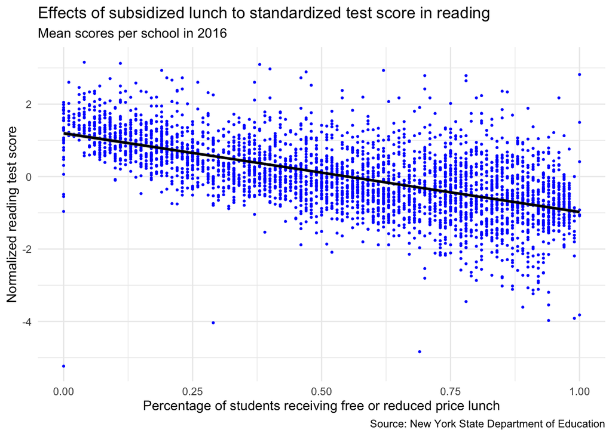

```r
#Add variable for the percentage of students that receive subsidized lunch
merged_schools06[, per_lunch_subsidy := lunch_subsidy/total_enroll]

#Initialize graph comparing test scores and percentage of students on lunch subsidy
subsidyplot <- merged_schools06[, .(per_lunch_subsidy = per_lunch_subsidy, z_ela_score = z_ela_score, z_math_score = z_math_score)] %>% ggplot() + theme_minimal()

#Scatterplot for reading scores
subsidyplot +
  geom_point(mapping = aes(per_lunch_subsidy, z_ela_score), color = "blue", size= 0.5) +
  geom_smooth(mapping = aes(per_lunch_subsidy, z_ela_score), color = "black", method = "lm") +
  labs(title = "Effects of subsidized lunch to standardized test score in reading", subtitle = "Mean scores per school in 2016", x="Percentage of students receiving free or reduced price lunch", y="Normalized reading test score", caption = "Source: New York State Department of Education")
```

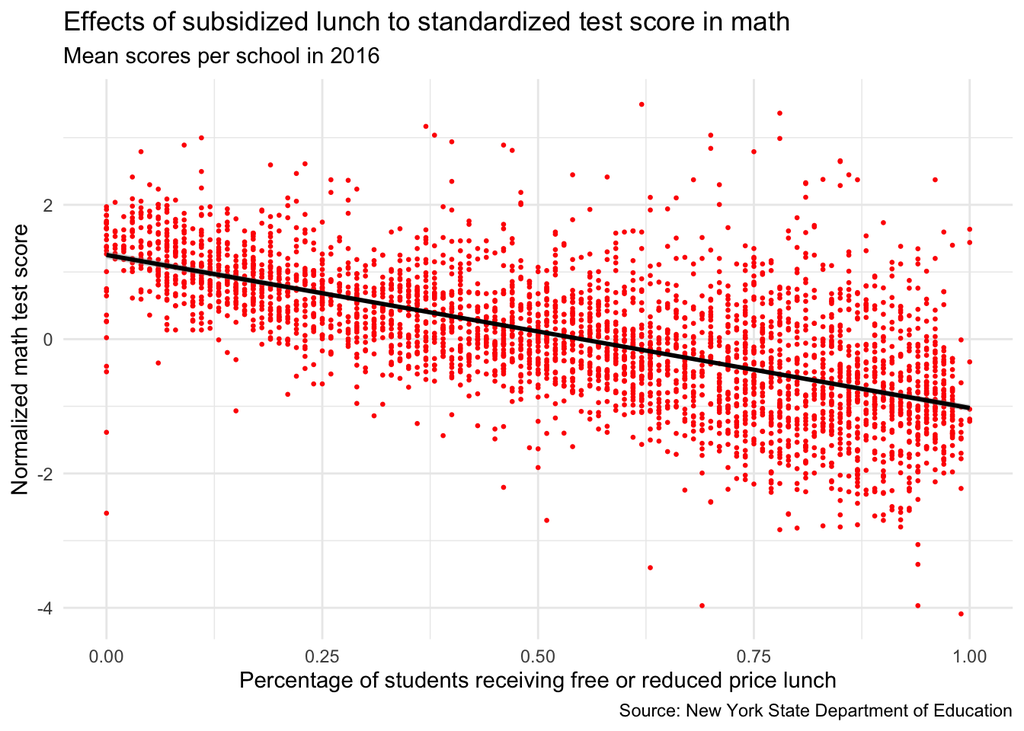

```r
#Scatterplot for math scores
subsidyplot +
  geom_point(mapping = aes(per_lunch_subsidy, z_math_score), color = "red", size = 0.5) +
  geom_smooth(mapping = aes(per_lunch_subsidy, z_math_score), color = "black", method = "lm") + labs(title = "Effects of subsidized lunch to standardized test score in math", subtitle = "Mean scores per school in 2016", x="Percentage of students receiving free or reduced price lunch", y="Normalized math test score", caption = "Source: New York State Department of Education")
```

Now we compare mean test scores in each poverty level.

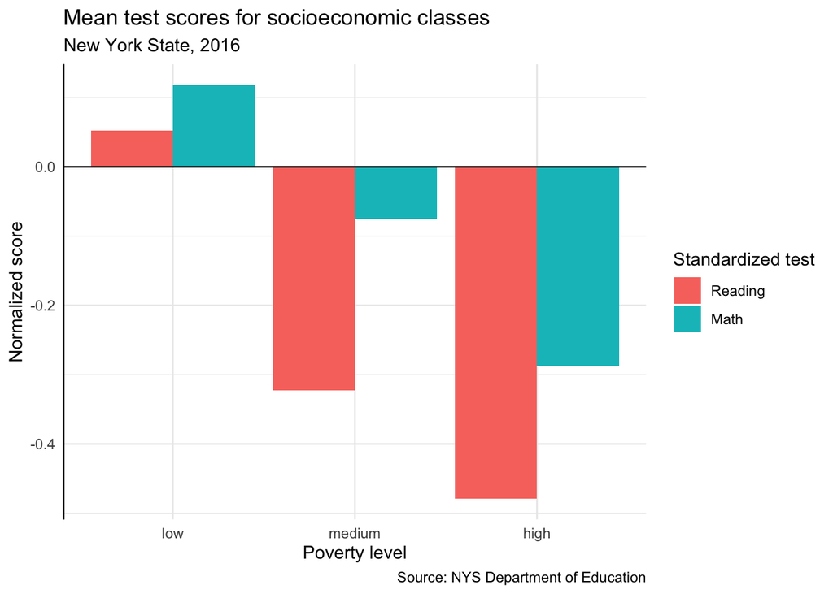

```r
#Create a new data.table that first groups the 2016 dataset by county, and then by poverty level. DT contains mean test scores
povtable <- merged_schools06[ ,.(reading_score = mean(z_ela_score, na.rm=T), math_score = mean(z_math_score, na.rm = T), poverty_level = unique(poverty_level)), by=county_name][,.(reading_score = mean(reading_score, na.rm=T), math_score = mean(math_score, na.rm = T)), by=poverty_level]

#Reshape table to be taller
povtable <- melt(povtable, id_vars = poverty_level, variable.name = "test_type", value.name = "score")

#Create a side-by-side bar chart for poverty level vs. test scores
ggplot(povtable) +
  geom_col(mapping=aes(x=poverty_level, y=score, group=test_type, fill=test_type), position = "dodge") +
  theme_minimal() + theme(axis.line.y.left = element_line()) + geom_hline(yintercept = 0) +
  scale_fill_discrete(name="Standardized test", labels = c("Reading", "Math")) +
  labs(title = "Mean test scores for socioeconomic classes", subtitle = "New York State, 2016", x = "Poverty level", y="Normalized score", caption = "Source: NYS Department of Education")
```

## Discussion

The following graphs represent a time-series comparison of mean reading and math scores (normalized for each year), segregated into socioeconomic class.

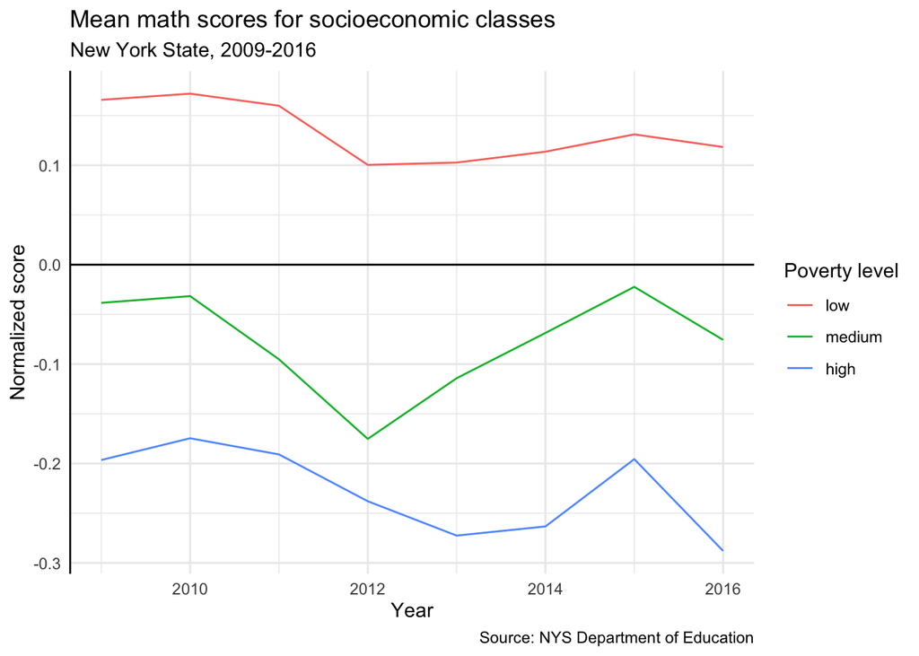

```r
#Construct a new data.table containing mean reading and math scores of schools, first grouped by county and year, then grouped by poverty level and year
yeartable <- merged_schools[county_name != "NA" & poverty_level != "NA", .(reading_score = mean(z_ela_score, na.rm=T), math_score = mean(z_math_score, na.rm = T), poverty_level = unique(poverty_level)), by = .(county_name, year)][,.(reading_score = mean(reading_score, na.rm=T), math_score = mean(math_score, na.rm = T)), by=.(poverty_level, year)]

#Reshape table to be taller (This analysis and the one below strongly resemble the one above. A better practice would definitely be to create a function that will do this for me)
yeartable <- melt(yeartable, id.vars = c("poverty_level", "year") , variable.name = "test_type", value.name = "score")

#Line graph that shows evolution of math scores over years for each poverty level
yeartable[test_type == "math_score"] %>%
ggplot() +
  geom_line(mapping = aes(x=year, y=score, group=poverty_level, col=poverty_level)) +
  theme_minimal() +
  theme(axis.line.y.left = element_line()) + geom_hline(yintercept = 0) +
  scale_color_discrete(name = "Poverty level") +
  labs(title = "Mean math scores for socioeconomic classes", subtitle = "New York State, 2009-2016", x = "Year", y = "Normalized score", caption = "Source: NYS Department of Education")
```

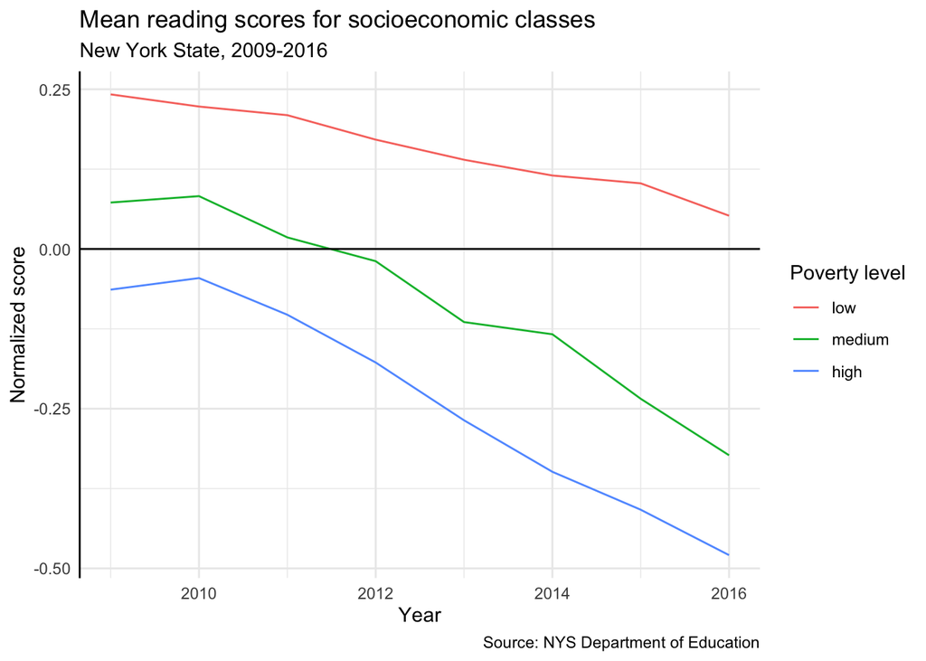

```r
#Very similar graph to one above, for reading scores
yeartable[test_type == "reading_score"] %>%
ggplot() + geom_line(mapping = aes(x=year, y=score, group=poverty_level, col=poverty_level)) +
  theme_minimal() +
  theme(axis.line.y.left = element_line()) + geom_hline(yintercept = 0) +
  scale_color_discrete(name = "Poverty level") +
  labs(title = "Mean reading scores for socioeconomic classes", subtitle = "New York State, 2009-2016", x = "Year", y = "Normalized score", caption = "Source: NYS Department of Education")
```

As shown, poverty level is negatively correlated with mean math and reading scores for each and every year analyzed: schools situated in socioeconomically higher counties get significantly higher scores in tests.

We will do a similar analysis for the percentage of students receiving free or reduced-price lunch, and divide schools up by levels of density.

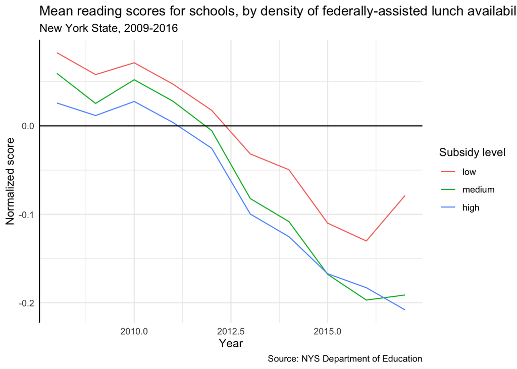

```r
#Add a new variable that shows percentage of students receiving free or reduced price lunch
merged_schools[, per_lunch_subsidy := (per_free_lunch + per_reduced_lunch)]

#Define cutoffs for student population that receive federally assisted lunch, from low density to high
lunch_cutoff = quantile(merged_schools$per_lunch_subsidy, c(0.33, 0.66), na.rm=T)

#Apply cutoffs to a new variable
merged_schools[per_lunch_subsidy < lunch_cutoff[1], subsidy_level := "low"]
merged_schools[per_lunch_subsidy >= lunch_cutoff[1] & per_lunch_subsidy < lunch_cutoff[2], subsidy_level :="medium"]
merged_schools[per_lunch_subsidy >= lunch_cutoff[2], subsidy_level := "high"]

#Change variable to a factor
merged_schools[, subsidy_level := factor(subsidy_level, levels = c("low", "medium", "high"))]

#Create a new data.table containing mean test scores, grouped by first year and county, then year and subsidy level
lunchtable <- merged_schools[county_name != "NA" & subsidy_level != "NA", .(reading_score = mean(z_ela_score, na.rm=T), math_score = mean(z_math_score, na.rm = T), subsidy_level = unique(subsidy_level)), by = .(county_name, year)][,.(reading_score = mean(reading_score, na.rm=T), math_score = mean(math_score, na.rm = T)), by=.(subsidy_level, year)]

#Reshape table
lunchtable <- melt(lunchtable, id.vars = c("subsidy_level", "year") , variable.name = "test_type", value.name = "score")

#Line graph for reading scores
lunchtable[test_type == "reading_score"] %>%
ggplot() +
  geom_line(mapping = aes(x=year, y=score, group=subsidy_level, col=subsidy_level)) +
  theme_minimal() +
  theme(axis.line.y.left = element_line()) + geom_hline(yintercept = 0) +
  scale_color_discrete(name = "Subsidy level") +
  labs(title = "Mean reading scores for schools, by density of federally-assisted lunch availability", subtitle = "New York State, 2009-2016", x = "Year", y = "Normalized score", caption = "Source: NYS Department of Education")
```

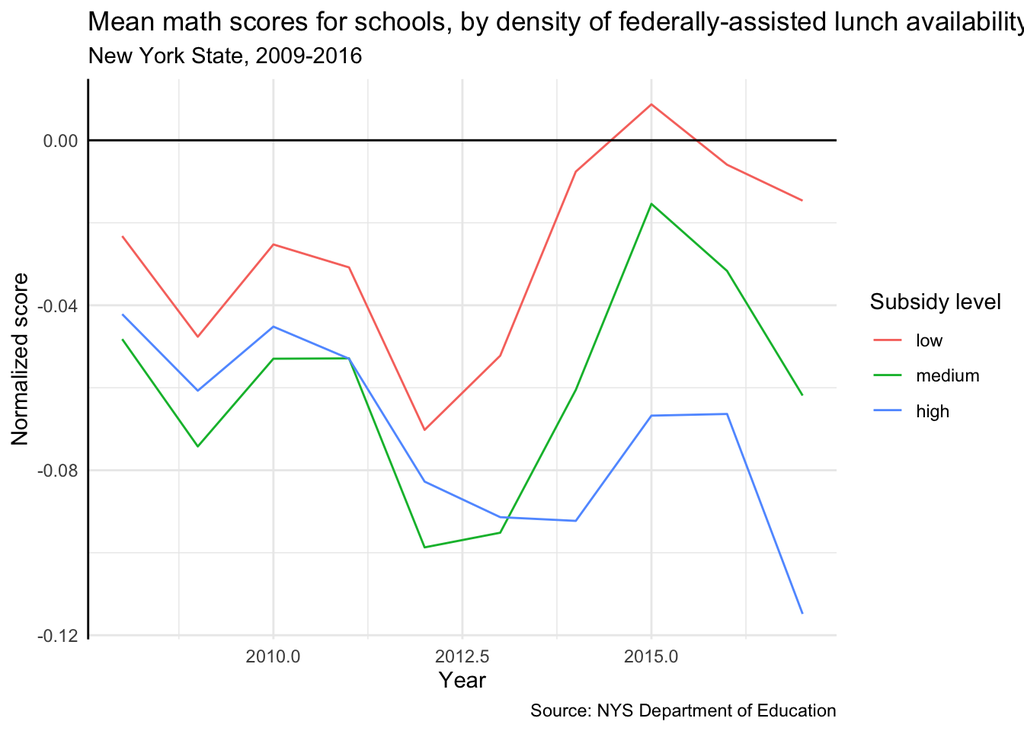

```r
#Line graph for math scores
lunchtable[test_type == "math_score"] %>%
ggplot() +
  geom_line(mapping = aes(x=year, y=score, group=subsidy_level, col=subsidy_level)) +
  theme_minimal() +
  theme(axis.line.y.left = element_line()) + geom_hline(yintercept = 0) +
  scale_color_discrete(name = "Subsidy level") +
  labs(title = "Mean math scores for schools, by density of federally-assisted lunch availability", subtitle = "New York State, 2009-2016", x = "Year", y = "Normalized score", caption = "Source: NYS Department of Education")
```

These graphs do not reveal much - since lunch subsidy is correlated with poverty level, it is not surprising to see low subsidy – low poverty – higher test scores. Also we can see that the normalized score does not add up to 0 for each year, probably due to gaps in score reporting.

Further study of this subject may include a further statistical analysis that looks at how lunch subsidy affects test scores, **controlled for** level of poverty. This analysis could be approximated by only looking within each poverty level and compare percent of students on subsidized lunch, but that doesn’t account for variations of income within poverty levels.